# Statistical Learning Final Project

# Install and Import Packages

```r
# Load the required packages
install.packages("readxl")
install.packages("factoextra")
install.packages("FactoMineR")
install.packages("kernlab")

library(readxl)
library(stats)
library(tidyverse)
library(caret)
library(kernlab)
library(FactoMineR)
library(factoextra)
library(e1071)
library(ggplot2)
```

# Import Data Set

```r
data <- read_csv("https://raw.githubusercontent.com/reisanar/datasets/master/super_bowl.csv")
```

# Make Data Frame

**This will help simplify binary operations**

```r
Date <- data$Date
SB <- data$SB
Attendance <- data$Attendance
QB_Winner <- data$QB_Winner
Coach_Winner <- data$Coach_Winner
Winner <- data$Winner
Winning_Pts <- data$Winning_Pts
QB_Loser <- data$QB_Loser
Coach_Loser <- data$Coach_Loser
Loser <- data$Loser
Losing_Pts <- data$Losing_Pts
MVP <- data$MVP
Stadium <- data$Stadium
City <- data$City
State <- data$State
Point_Difference <- data$Point_Difference
Referee <- data$Referee
Umpire <- data$Umpire
Head_Linesman <- data$Head_Linesman
Line_Judge <- data$Line_Judge
Field_Judge <- data$Field_Judge
Back_Judge <- data$Back_Judge
Side_Judge <- data$Side_Judge


Average_Points <- (sum(data$Winning_Pts) + sum(data$Losing_Pts)) / 52
Average_Points
```

```
[1] 46.80769
```

```r
DataFrame <- data.frame(Date,SB,Attendance,QB_Winner,Coach_Winner,Winner,Winning_Pts,QB_Loser,Coach_Loser,Loser,Losing_Pts,MVP,Stadium,City,State,Point_Difference,Referee,Umpire,Head_Linesman,Line_Judge,Field_Judge,Back_Judge,Side_Judge)
```

# PCA (Principal-Component Analysis)

## Utilizing prcomp to reduce dimensionality

### Select the columns you want to use for PCA

```r
selected_cols <- c("Attendance", "Winning_Pts", "Losing_Pts", "Point_Difference")
```

### Subset the data using the selected columns

```r
data_subset <- data[selected_cols]
```

### Perform PCA

```r
pca <- prcomp(data_subset, scale = TRUE)
```

### Extract the principal components

```r
pcs <- pca$x
```

### Print the principal components

```r
print(pcs)
```

```
               PC1          PC2           PC3           PC4
 [1,] -1.158478516 -0.346790250 -1.6890519722 -1.110223e-16
 [2,] -0.578646327 -0.170007088 -0.2674416241  1.110223e-16
 [3,]  1.010629447 -1.706014122 -0.4677476758 -4.218847e-15
 [4,]  0.024431838 -1.537767652 -0.0005381818 -2.858824e-15
 [5,]  1.595452549 -1.013019008  0.0930178271 -3.441691e-15
 [6,] -0.522929927 -2.018586990 -0.0941547707 -3.219647e-15
 [7,]  1.173209676 -2.061915334  0.9321275158 -4.551914e-15
 [8,] -0.047456209 -1.335534530 -0.8214316011 -2.692291e-15
 [9,]  0.867420763 -1.939640292  0.0272043425 -4.385381e-15
[10,]  1.319404828 -0.331420647  0.3053249304 -1.887379e-15
[11,] -0.647492605 -0.735711734  2.3639724662 -1.387779e-16
[12,] -0.180583295 -0.924375962 -0.3037331424 -1.720846e-15
[13,]  0.857742155  1.999507241  0.6680648408  2.886580e-15
[14,] -0.005386568 -0.146434225  2.5861226061  4.163336e-16
```

[output cut: 38 more lines]

## PCA Graphing

*PCA* includes many different graphing techniques, which is shown below:

- **get_eigenvalue(res.pca)**: Extract the eigenvalues/variances of principal components
- **fviz_eig(res.pca)**: Visualize the eigenvalues
- **get_pca_ind(res.pca)**, **get_pca_var(res.pca)**: Extract the results for individuals and variables, respectively.
- **fviz_pca_ind(res.pca)**, **fviz_pca_var(res.pca)**: Visualize the results individuals and variables, respectively.
- **fviz_pca_biplot(res.pca)**: Make a biplot of individuals and variables.

## Perform PCA and Plots the Variable and Individuals Graph

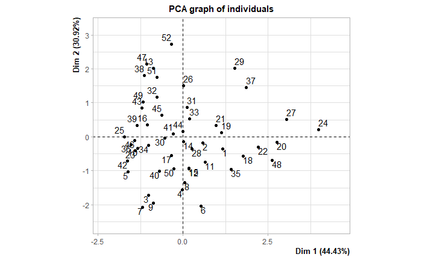

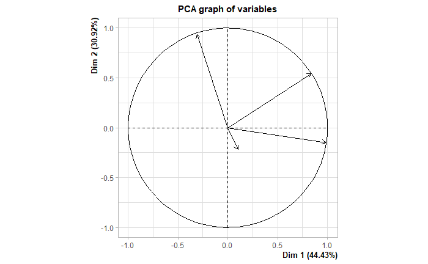

```r
pca <- PCA(data_subset, scale.unit = TRUE, ncp = 5)
```